# 第13回 事前学習

作者

J22069 野倉悠正

公開

2026年7月13日

## 1 7月中のやること

- データベースサーバー（Flask）にフロントエンドを配信する機能の追加
- バックエンドをDockerイメージにするためのファイルを作成
- GitHub Actionsで自動デプロイワークフローを作成（👈 今回）
- Gunicornを起動するSystemdユニットを作成（👈 今回）
- フロントエンドに生徒用ファイルの変更内容が反映されるように改良（第14回までに）
- フロントエンドに生徒用ファイルをプレビューする機能の追加（第14回までに）
- フロントエンドに修了証を表示させる機能の追加（第14回までに）
- フロントエンドをビルドし、サーバーに配置（👈 今回）
- ゼミサーバーのApacheを、`www.sekilab.org/sakaki-map/`で配信されるように変更（👈 今回）
- 生徒・保護者用のマニュアルを作成（第14回までに）
- 「さかき思い出マップ」で変更した内容を「信州おまつりナビ」に反映
- ネイティブアプリへの変更の可用性の再調査・検討

## 2 GitHub Actionsで自動デプロイワークフローを作成

### 2.1 Actions Secretsの保存（＞ 第12回より）

GitHub Actions でパスワードやトークンなどの機密情報を安全に扱うための仕組みが **Actions Secrets** である。 ここに保存した値はワークフローファイル内で `${{ secrets.DOCKERHUB_USERNAME }}` のように参照でき、ログにはマスクされて（隠されて）出力されるため、安全に利用できる。

今回のワークフローを実行するためには、以下の5つのシークレットを GitHub リポジトリ（Settings > Secrets and variables > Actions）に保存する必要がある。

- `DOCKERHUB_USERNAME`: Docker Hub のユーザー名
- `DOCKERHUB_TOKEN`: Docker Hub のアクセストークン
- `SERVER_HOST`: デプロイ先サーバーのホスト名（IPアドレスなど）
- `SERVER_USER`: デプロイ先サーバーのSSHユーザー名
- `SERVER_SSH_KEY`: デプロイ先サーバーに接続するためのSSH秘密鍵

Actions Secretsの新規保存

[figure not shown]

### 2.2 Docker Hubのアクセストークンの取得

※ ’25年度技術報告書 [「5.6.4 Docker Hubへのログイン（CLI上）」内の「💡ソーシャルログインを使用していてパスワードがない場合」](https://yumachin2003.github.io/docs/2025年度技術報告書#:~:text=ソーシャルログインを使用していてパスワードがない場合)から引用

「Googleで続行」などソーシャルログインを使用していてパスワードがない場合は、**Personal access tokens（PAT）**を使用することができる。

1. [アカウント設定](https://app.docker.com/)を開き、「Settings」＞「Personal access tokens」を開く。
2. 「Generate new token」からトークンを作成。
3. 下図の赤枠内がトークンなのでこれをパスワードの代わりに入力する。

[figure not shown]

### 2.3 ワークフロー用のSSH鍵ペアの作成

ワークフロー用にGitHubからサーバーに接続するため、SSH鍵ペアを作成する。

**重要**

既に個人用に作成した鍵ペアがある場合、新たに作成しどのクライアントからのアクセスかを区別できるようにすることを推奨する。

```
bash
```

```bash
ssh-keygen -t ed25519 -f ~/.ssh/GitHubActions_sakaki-map -N "" -C "GitHubActions_sakaki-map"
```

**実行結果**

ターミナルの出力

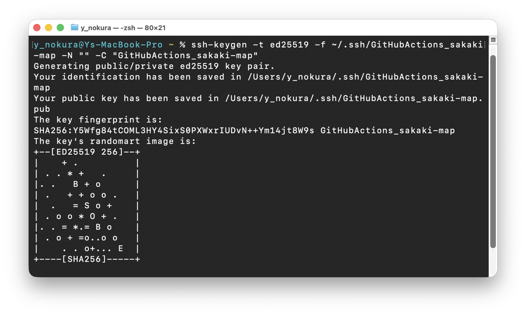

Finderに表示された公開鍵と秘密鍵

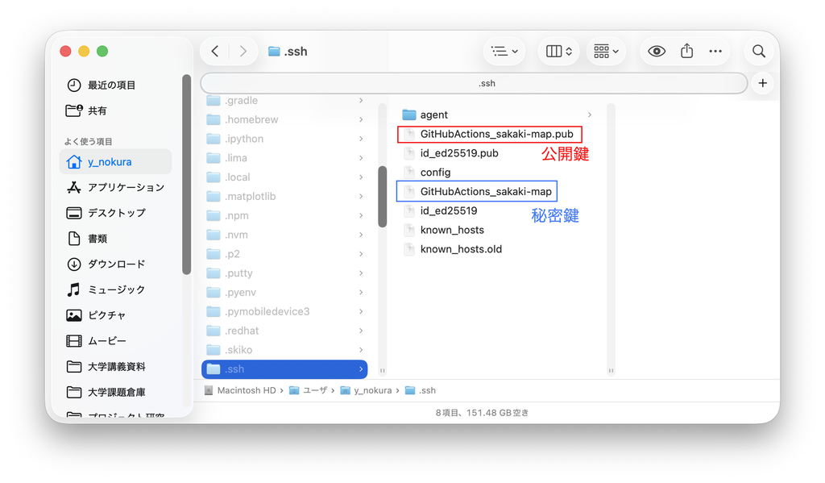

**ヒントオプションの解説**

- `-t`: 鍵の種類を指定。だいたい`ed25519`を使っておけばOK。詳しくは[ed25519 をさらっと理解する](https://zenn.dev/kohno/articles/cd33239bf12e5f) を参照。
- `-f`: 保存先の指定。今回は既存の鍵と区別するため、`GitHubActions_sakaki-map`という名前を指定する。
- `-N`: パスフレーズ（秘密鍵を開く際に必要となるパスワードのようなもの）の設定。`""`にすることにより、パスフレーズの設定をスキップし、自動化の際にパスフレーズを求められないようにする。
- `-C`: コメントオプション。ファイル名と同じく、管理しやすいように`GitHubActions_sakaki-map`とした。

`~/.ssh`に`GitHubActions_sakaki-map`（秘密鍵）と`GitHubActions_sakaki-map.pub`（公開鍵）が生成されたら、以下を実行してサーバーに公開鍵を追加する。

```
bash
```

```bash
cat ~/.ssh/GitHubActions_sakaki-map.pub | ssh j22069yn@133.242.152.98 "mkdir -p ~/.ssh && cat >> ~/.ssh/authorized_keys"
```

さらに、`GitHubActions_sakaki-map`（秘密鍵）の方をActions Secretsにも忘れずに追加する。

**重要**

秘密鍵を追加するのは`-----BEGIN OPENSSH PRIVATE KEY-----`と`-----END OPENSSH PRIVATE KEY-----`を含む、全文である。

また、必ずブラウザでGitHubのリポジトリ設定を開き、「Actions secrets and variables」の設定画面から追加すること。もしVS Codeの「GitHub Actions」拡張機能から追加する場合は、秘密鍵に改行を含むため、うまく反映されない。

### 2.4 ワークフロー用のSSH鍵のセキュリティ設定

万が一SSH秘密鍵が漏洩してしまうと、SSHが自由に行えてしまいセキュリティ的に危険である。そのため、サーバー上の`authorized_keys`ファイルに以下のような制限を記述することで、万が一漏洩しても全てのコマンドを使うことはできないため、リスクを軽減することが可能である。

**ノート**

’25年度技術報告書の [「4.2.2 サーバーへの登録」・「4.2.3 実行コマンドの制限スクリプト」](https://yumachin2003.github.io/docs/2025年度技術報告書#:~:text=4.2.2%20サーバーへの登録) を参考にして実装したので、こちらも参照してほしい。

制限の内容としては、

1. `scp*`、`*sftp-server*`、`internal-sftp`、`tar*`、`mkdir*`、`rm*`のコマンドのみ許可する（`command="GitHubActions_restriction.sh"`）。
2. 対話的ログインの禁止（`no-pty`）。
3. サーバーを踏み台にした他のホストへのアクセスを防ぐため、SSHエージェント転送を禁止（`no-agent-forwarding`）。
4. GUI画面の転送（X11転送）を禁止（`no-X11-forwarding`）。

#### `GitHubActions_restriction.sh`の作成

まず、サーバー上に1.の特定コマンド以外はエラーを返すスクリプトファイルを作成する。

```
~/.ssh/GitHubActions_restriction.sh
```

```bash
#!/bin/bash

case "$SSH_ORIGINAL_COMMAND" in
    scp*|*sftp-server*|internal-sftp|tar*|mkdir*|rm*)
        $SSH_ORIGINAL_COMMAND
        ;;
    "")
        sleep infinity
        ;;
    *)
        echo "Access Denied: Only SCP/SFTP and specific deployment commands are allowed." >&2
        exit 1
        ;;
esac
```

**1**

`scp`や`sftp`のファイル転送や、`tar`、`mkdir`、`rm`などの特定のデプロイ用コマンドのみ実行を許可し、そのまま実行させる。

**2**

コマンドが指定されずに接続された場合、接続を維持するために無期限に待機させる。

**3**

それ以外の許可されていないコマンドが実行された場合は、エラーメッセージを出力し、アクセスを拒否して終了させる。

#### `authorized_keys`への登録

次に、`authorized_keys`ファイルをnanoエディタなどで開き、2.3で作成した`GitHubActions_sakaki-map`が末尾の公開鍵があるので、その行の先頭を以下のように書き換える。

```
~/.ssh/authorized_keys
```

```
no-pty, no-agent-forwarding, no-X11-forwarding, command="/home/j22069yn/.ssh/GitHubActions_restriction.sh" ssh-ed25519 <公開鍵> GitHubActions_sakaki-map
```

### 2.5 ワークフローの実行失敗

[第12回](https://yumachin2003.github.io/docs/zemi26/12#:~:text=5.1%20デプロイのワークフローの作成)で作ったワークフローを含む変更をプッシュし、ワークフローをトリガーさせたところ、以下のようなエラーが発生した。

[figure not shown]

```
エラー部分抜粋
```

```
2026/07/12 11:58:10 error copy file to dest: ***, error message: Process exited with status 126
drone-scp error: error copy file to dest: ***, error message: Process exited with status 126
```

この126エラーは、Ubuntuにおいて**「コマンド（またはスクリプト）は存在しますが、実行権限がない**ことを意味する。そのため、`chmod`コマンドで実行権限を付与する必要がある。

**ヒント`chmod`とパーミッション**

`chmod`コマンドは、ファイルやディレクトリのパーミッション（権限）を変更するためのコマンドである。

ファイルには、**3つの権限**と**3つの所有者**に対応するパーミッションが設定されている。

3つの権限

|  | r | w | x |
| --- | --- | --- | --- |
| 覚え方 | **R**ead | **W**rite | E**x**ecute |
| できること | 読み取り | 書き込み | 実行 |

3つの所有者

|  | u | g | o |
| --- | --- | --- | --- |
| 覚え方 | **U**ser | **G**roup | **O**ther |
| 対象 | ファイル 所有者 | 所有者の グループ全員 | 他の全ての ユーザー |

`ls -l`コマンドで、ファイルに付与されている権限が次のように表示される。

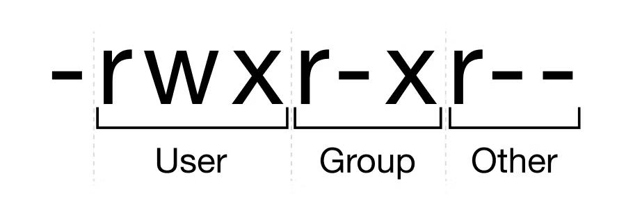

詳しくは、[chmodを理解する #初心者 - Qiita](https://qiita.com/kentosity/items/814a11d7e0c475bea3d8) を参照してほしい。

以下のコマンドで実行権限を付与（`+x`）する。

```
bash
```

```bash
chmod +x ~/.ssh/GitHubActions_restriction.sh
```

これで、全てのユーザーが`GitHubActions_restriction.sh`を実行可能になる。

**ノート**

全てのユーザーに実行権限を付与しているのは少し心配かと思うが、`.ssh`フォルダには**700パーミッション**という「所有者のみアクセス可能」というパーミッションがデフォルトでかかっており、そもそもフォルダの内部にはアクセスできない状態になっている。

ワークフローの再実行を行うと、今度は正常にバックエンドのDockerイメージの作成・プッシュとフロントエンドの静的ファイルの移動が完了した。

ワークフローの実行成功

[figure not shown]

サーバーへのフロントエンドの静的ファイルの移動成功

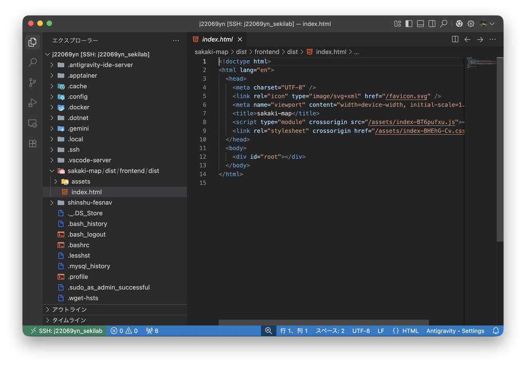

Docker Hubへのバックエンドのイメージのプッシュ成功

[figure not shown]

## 3 フロントエンドをビルドし、サーバーに配置

この作業はGitHub Actionsを用いて自動化した。

最終版のワークフローファイルは以下。

```
/.github/workflows/buildAndDeploy.yml
```

```yaml
name: Build and Deploy

on:
  push:
    branches: [ main ]

jobs:
  build-and-deploy:
    runs-on: ubuntu-latest
    steps:
      - uses: actions/checkout@v4

      # 1. フロントエンドのビルド
      - name: Build Frontend
        run: |
          cd frontend
          npm install
          npm run build

      - name: Prepare deploy folder
        run: |
          mkdir -p dist
          cp -r frontend/dist/* dist/

      # 2. バージョンタグの自動取得
      - name: Get latest tag and increment
        id: auto_tag
        run: |
          HUB_TOKEN=$(curl -s -H "Content-Type: application/json" \
            -X POST \
            -d "{\"username\": \"${{ secrets.DOCKERHUB_USERNAME }}\", \"password\": \"${{ secrets.DOCKERHUB_TOKEN }}\"}" \
            https://hub.docker.com/v2/users/login/ | jq -r .token)

          REPO="${{ secrets.DOCKERHUB_USERNAME }}/sakaki-map-backend"
          LATEST_TAG=$(curl -s -H "Authorization: Bearer ${HUB_TOKEN}" \
            "https://hub.docker.com/v2/repositories/${REPO}/tags/?page_size=1" | jq -r '.results[0].name')

          COMMIT_MSG="${{ github.event.head_commit.message }}"

          if [[ $COMMIT_MSG =~ v([0-9.]+) ]]; then
            NEW_TAG="${BASH_REMATCH[1]}"
          else
            if [ "$LATEST_TAG" == "null" ] || [ "$LATEST_TAG" == "latest" ] || [[ ! $LATEST_TAG =~ ^[0-9.]+$ ]]; then
              NEW_TAG="1.0"
            else
              NEW_TAG=$(echo "$LATEST_TAG + 0.1" | bc | xargs printf "%.1f")
            fi
          fi
          echo "tag=${NEW_TAG}" >> $GITHUB_OUTPUT

      # 3. バックエンドの Docker イメージビルド＆プッシュ
      - name: Login to Docker Hub
        uses: docker/login-action@v3
        with:
          username: ${{ secrets.DOCKERHUB_USERNAME }}
          password: ${{ secrets.DOCKERHUB_TOKEN }}

      - name: Build and push Backend
        uses: docker/build-push-action@v5
        with:
          context: ./backend
          push: true
          tags: |
            ${{ secrets.DOCKERHUB_USERNAME }}/sakaki-map-backend:v${{ steps.auto_tag.outputs.tag }}
            ${{ secrets.DOCKERHUB_USERNAME }}/sakaki-map-backend:latest

      # 4. SCPでサーバーへ転送
      - name: Copy frontend to server
        uses: appleboy/scp-action@v0.1.7
        with:
          host: ${{ secrets.SERVER_HOST }}
          username: ${{ secrets.SERVER_USER }}
          key: ${{ secrets.SERVER_SSH_KEY }}
          source: "frontend/dist/*"
          target: "/home/j22069yn/sakaki-map/dist"
```

**1**

前版であった「`Prepare deploy folder`」ステップ（ファイルを一旦`dist`にコピーする処理）は不要となったため削除した（上記コード内には変更箇所として残している）。

**2**

転送元（`source`）を直接`frontend/dist/*`に変更した。これにより、1のステップを省きワークフローを簡略化している。

**3**

転送先（`target`）のパスの末尾に`/dist`を追記し、適切なディレクトリに直接配置されるように変更した。